# Evaluación final

[figure not shown]

## Pasos previos

#### Cargar paquetes

```r
library(pacman)

p_load(tidyverse,  # Manipulación y visualización de datos
       openxlsx,   # Importar archivos excel
       patchwork,  # Manipulación de gráficos
       psych,      # Estadisticos descriptivos
       skimr,      # Estadisticos descriptivos
       car,        # Análisis de homocedasticidad
       corrr,      # Análisis de correlación
       effectsize) # Tamaño del efecto
```

## Actividad 1

#### Importa la base de datos `data3_clean` y guárdala en un objeto

```r
burnout_df <- readxl::read_excel("data3_clean.xlsx")
```

| sexo | convive | escuela | edad | ase1 | ase2 | ase3 | ase4 | ase5 | ase6 | ase7 | ase8 | ase9 | ase10 | ase11 | ase12 | ase13 | ase14 | ase15 | ase16 | ase17 | ase18 | ase19 | ase20 | ase21 | ase22 | ase23 | ase24 | ase25 | ase26 | … |
| --- | --- | --- | --- | --- | --- | --- | --- | --- | --- | --- | --- | --- | --- | --- | --- | --- | --- | --- | --- | --- | --- | --- | --- | --- | --- | --- | --- | --- | --- | --- |
| Mujer | Solo | Ciencias Sociales | 18 | 2 | 2 | 2 | 1 | 2 | 2 | 2 | 1 | 3 | 2 | 2 | 2 | 1 | 1 | 2 | 1 | 1 | 2 | 2 | 1 | 1 | 3 | 1 | 1 | 2 | 2 | … |
| Mujer | Solo | Vocación salud | 20 | 3 | 4 | 3 | 3 | 3 | 3 | 3 | 4 | 3 | 3 | 3 | 3 | 3 | 3 | 3 | 3 | 3 | 3 | 3 | 3 | 3 | 3 | 3 | 1 | 2 | 4 | … |
| Mujer | Solo | Vocación salud | 20 | 3 | 3 | 4 | 4 | 4 | 4 | 4 | 4 | 4 | 3 | 3 | 3 | 2 | 3 | 3 | 3 | 2 | 3 | 3 | 3 | 2 | 3 | 3 | 3 | 2 | 3 | … |
| Hombre | Con familia | Ciencias | 18 | 3 | 3 | 3 | 4 | 4 | 4 | 3 | 3 | 3 | 3 | 2 | 3 | 3 | 4 | 3 | 3 | 3 | 3 | 3 | 3 | 3 | 3 | 3 | 1 | 3 | 3 | … |
| Mujer | Con familia | Vocación salud | 19 | 3 | 3 | 3 | 3 | 3 | 3 | 3 | 3 | 3 | 3 | 3 | 3 | 3 | 3 | 3 | 3 | 3 | 3 | 3 | 3 | 3 | 3 | 3 | 3 | 3 | 3 | … |
| Mujer | Con familia | Ciencias | 19 | 3 | 3 | 3 | 4 | 4 | 3 | 3 | 3 | 4 | 4 | 3 | 4 | 3 | 3 | 3 | 3 | 3 | 3 | 3 | 3 | 3 | 4 | 4 | 3 | 3 | 3 | … |

## Actividad 2

#### Selecciona todas las variables sociodemográficas. Luego filtra a los participantes de la escuela “Vocación salud”, que sean mujeres y mayores de edad. Finalmente, guárdalo en un objeto llamado “demograficos” y expórtalo en un archivo excel con el mismo nombre

```r
demograficos <- burnout_df %>%
  select(sexo:edad) %>%
  filter(escuela == "Vocación salud",
         sexo    == "Mujer",
         edad    >=  18)
```

| sexo | convive | escuela | edad |
| --- | --- | --- | --- |
| Mujer | Solo | Vocación salud | 20 |
| Mujer | Solo | Vocación salud | 20 |
| Mujer | Con familia | Vocación salud | 19 |
| Mujer | Con familia | Vocación salud | 19 |
| Mujer | Con familia | Vocación salud | 19 |
| Mujer | Con familia | Vocación salud | 18 |

```r
write.xlsx(demograficos, "demograficos.xlsx")
```

## Actividad 3

#### Halla el puntaje total de la escala de *burnout* y colócale el nombre “bur_total”, luego halla el puntaje total de la escala de *autoeficacia académica* y colócale el nombre “ase_total”. Finalmente, categoriza estos puntajes totales y usa los nombres “bur_cat” y “ase_cat” para las variables categóricas creadas.

##### Crear variables totales para burnout y autoeficacia académica

```r
burnout_df <- burnout_df %>%
              rowwise() %>%
              mutate(bur_total = sum(c_across(bur1:bur24))) %>%
              ungroup()
```

```r
burnout_df <- burnout_df %>%
              rowwise() %>%
              mutate(ase_total = sum(c_across(ase1:ase31))) %>%
              ungroup()
```

##### Categorizar variables de burnout y autoeficacia académica

```r
burnout_df <- burnout_df %>%
  mutate(
    bur_cat = case_when(bur_total <= 48 ~ "leve",
                        bur_total <  97 ~ "moderado",
                        bur_total >= 97 ~ "severo")
    )
```

```r
burnout_df <- burnout_df %>%
  mutate(
    ase_cat = case_when(ase_total <  62 ~ "baja",
                        ase_total <= 93 ~ "moderada",
                        ase_total >= 94 ~ "alta")
  )
```

| bur_total | bur_cat | ase_total | ase_cat |
| --- | --- | --- | --- |
| 124 | severo | 53 | baja |
| 62 | moderado | 95 | alta |
| 39 | leve | 96 | alta |
| 76 | moderado | 93 | moderada |
| 10 | leve | 93 | moderada |
| 18 | leve | 103 | alta |

## Actividad 4

#### Halla la frecuencia en porcentajes de burnout (leve, moderado, severo) y de autoeficacia académica (baja, moderada y alta) en mujeres que viven solas de la escuela de vocación de salud. (Las frecuencias para cada variable deben tener códigos separados).

```r
burnout_df %>%
  filter(sexo == "Mujer",
         convive == "Solo",
         escuela == "Vocación salud") %>%
  count(bur_cat) %>%
  mutate(porcentaje = n/sum(n)*100)
```

[output not shown]

```r
burnout_df %>%
  filter(sexo == "Mujer",
         convive == "Solo",
         escuela == "Vocación salud") %>%
  count(ase_cat) %>%
  mutate(porcentaje = n/sum(n)*100)
```

[output not shown]

## Actividad 5

#### Realiza un resumen descriptivo de *burnout* y *autoeficacia académica* según las variable *sexo* y *convive*

```r
# Según la variable sexo
burnout_df %>%
  select(bur_total, ase_total, sexo) %>%
  describeBy(group = .$sexo)
```

```
##
##  Descriptive statistics by group
## group: Hombre
##           vars  n  mean    sd median trimmed   mad min max range  skew kurtosis
## bur_total    1 15 91.27 26.11     95   92.08 31.13  48 124    76 -0.24    -1.47
## ase_total    2 15 73.20 13.93     68   72.08 10.38  57 104    47  0.75    -0.67
## sexo*        3 15  1.00  0.00      1    1.00  0.00   1   1     0   NaN      NaN
##             se
## bur_total 6.74
## ase_total 3.60
## sexo*     0.00
## ------------------------------------------------------------
## group: Mujer
##           vars  n  mean    sd median trimmed   mad min max range  skew kurtosis
## bur_total    1 54 81.65 36.51   94.0   84.43 37.06  10 125   115 -0.48    -1.24
## ase_total    2 54 74.91 16.09   67.5   74.18 11.12  44 114    70  0.50    -0.82
## sexo*        3 54  1.00  0.00    1.0    1.00  0.00   1   1     0   NaN      NaN
##             se
## bur_total 4.97
## ase_total 2.19
## sexo*     0.00
```

```r
# Según la variable convive
burnout_df %>%
  select(bur_total, ase_total, convive) %>%
  describeBy(group = .$convive)
```

```
##
##  Descriptive statistics by group
## group: Con familia
##           vars  n  mean    sd median trimmed   mad min max range  skew kurtosis
## bur_total    1 46 82.35 35.77     78   84.84 54.11  10 125   115 -0.45    -1.14
## ase_total    2 46 73.76 15.29     67   73.13 14.83  44 104    60  0.41    -0.98
## convive*     3 46  1.00  0.00      1    1.00  0.00   1   1     0   NaN      NaN
##             se
## bur_total 5.27
## ase_total 2.26
## convive*  0.00
## ------------------------------------------------------------
## group: Solo
##           vars  n  mean    sd median trimmed   mad min max range  skew kurtosis
## bur_total    1 23 86.52 32.62    100   89.16 20.76  14 124   110 -0.70    -0.96
## ase_total    2 23 76.09 16.32     68   74.63 10.38  53 114    61  0.75    -0.69
## convive*     3 23  1.00  0.00      1    1.00  0.00   1   1     0   NaN      NaN
##            se
## bur_total 6.8
## ase_total 3.4
## convive*  0.0
```

## Actividad 6

#### Visualiza el comportamiento (distribución de puntajes) de las variables *burnout* y *autoeficacia académica*, utiliza colores a tu elección, junta ambos gráficos y exportalos con el nombre “puntajes_variables”. Asimismo coloca etiquetas con los nombres que consideres adecuados y que describan el gráfico (título, subtítulo, X y Y)

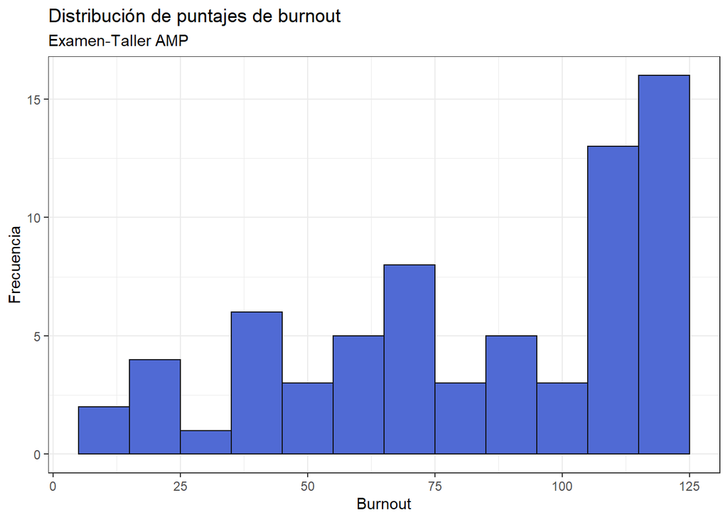

```r
# Elaborar histograma de la variable burnout
p1 <- burnout_df %>%
  ggplot(aes(x = bur_total)) +
  geom_histogram(binwidth = 10,
                 color = "#121317",
                 fill  = "#506AD4") +
  labs(
    title = "Distribución de puntajes de burnout",
    subtitle = "Examen-Taller AMP",
    x = "Burnout",
    y = "Frecuencia"
  ) +
  theme_bw()
```

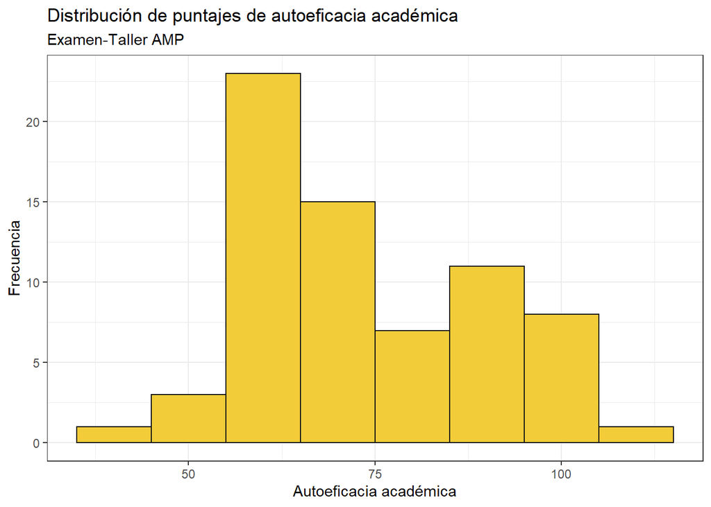

```r
# Elaborar histograma de la variable autoeficacia academica
p2 <- burnout_df %>%
  ggplot(aes(x = ase_total)) +
  geom_histogram(binwidth = 10,
                 color = "#121317",
                 fill  = "#F2CC39") +
  labs(
    title = "Distribución de puntajes de autoeficacia académica",
    subtitle = "Examen-Taller AMP",
    x = "Autoeficacia académica",
    y = "Frecuencia"
  ) +
  theme_bw()
```

```r
# Unir gráficos
p3 <- p1 + p2
```

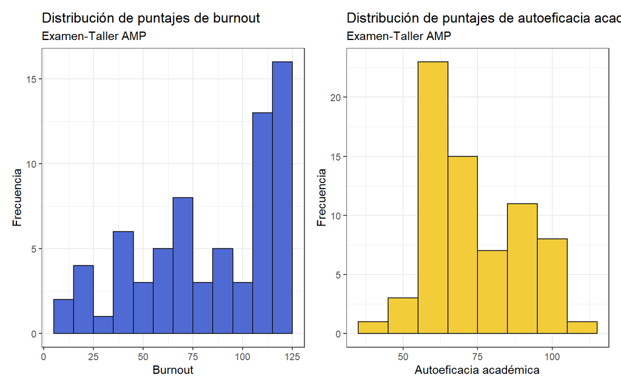

```r
# Exportar gráfico
ggsave(filename = "puntajes_variables.jpg",
       plot = p3,
       height = 4,
       width = 8,
       scale = 1.5,
       dpi = 300)
```

## Actividad 7

#### Realiza un gráfico de barras de la variable bur_cat que brinde la información mediante porcentajes. Así mismo utiliza colores e incluye las etiquetas, posteriormente expórtalo con el nombre “barras_variables”

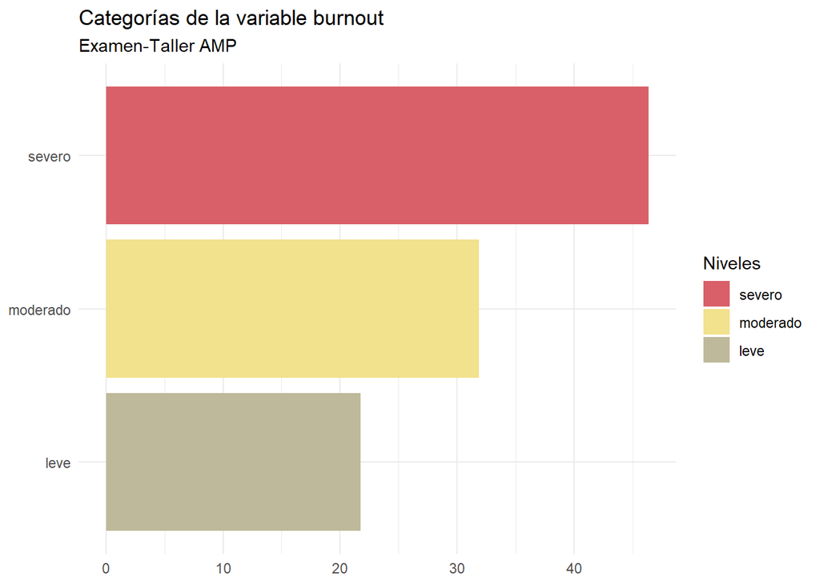

```r
p4 <- burnout_df %>%
  count(bur_cat) %>%
  mutate(porcentaje = n/sum(n)*100) %>%
  ggplot(aes(x = porcentaje,
             y = bur_cat,
             fill = bur_cat)) +
  geom_col() +
  scale_fill_manual("Niveles",
                    values = c("severo" = "#D95F69",
                               "moderado" = "#F2E18D",
                               "leve" = "#BFB99B")) +
  labs(title = "Categorías de la variable burnout",
       subtitle = "Examen-Taller AMP",
       x = NULL,
       y = NULL) +
  theme_minimal()
```

```r
# Exportar gráfico
ggsave(filename = "barras_variables.jpg",
       plot = p4,
       height = 4,
       width = 8,
       scale = 1.5,
       dpi = 300)
```

## Actividad 8

#### Evalúa el supuesto de normalidad para las variables *burnout* y *autoeficacia académica* según el *sexo*; y visualiza la normalidad en un histograma simple. Analiza el supuesto de homocedasticidad y brinda una interpretación para ambos supuestos.

##### *Evaluar el supuesto de normalidad (Shapiro-Wilk test)*

```r
# Burnout y sexo
tapply(burnout_df$bur_total,
       burnout_df$sexo,
       shapiro.test)
```

```
## $Hombre
##
##  Shapiro-Wilk normality test
##
## data:  X[[i]]
## W = 0.92082, p-value = 0.1983
##
##
## $Mujer
##
##  Shapiro-Wilk normality test
##
## data:  X[[i]]
## W = 0.88445, p-value = 8.613e-05
```

```r
# Autoeficacia académica y sexo
tapply(burnout_df$ase_total,
       burnout_df$sexo,
       shapiro.test)
```

```
## $Hombre
##
##  Shapiro-Wilk normality test
##
## data:  X[[i]]
## W = 0.90872, p-value = 0.1294
##
##
## $Mujer
##
##  Shapiro-Wilk normality test
##
## data:  X[[i]]
## W = 0.92655, p-value = 0.002668
```

> <sup>Ambas variables no cumplen el supuesto de normalidad</sup>

##### *Evaluar el supuesto de homocedasticidad (Levene test)*

```r
# Burnout y sexo
leveneTest(burnout_df$bur_total ~ factor(burnout_df$sexo))
```

|  | Df | F value | Pr(>F) |
| --- | --- | --- | --- |
| group | 1 | 2.92275 | 0.09196698 |
|  | 67 | NA | NA |

```r
# Autoeficacia académica y sexo
leveneTest(burnout_df$ase_total ~ factor(burnout_df$sexo))
```

|  | Df | F value | Pr(>F) |
| --- | --- | --- | --- |
| group | 1 | 0.5215013 | 0.472715 |
|  | 67 | NA | NA |

> <sup>Ambas variables cumplen el supuesto de homocedasticidad</sup>

## Actividad 9

#### A partir de lo hallado en los supuestos realiza la comparación de grupos para cada variable (*burnout* y *autoeficacia académica*) según la variable *sexo*. Asimismo, halla el tamaño del efecto y brinda una interpretación de los resultados.

##### *Evaluar si existen diferencias entre los grupos*

```r
# Burnout y sexo
wilcox.test(burnout_df$bur_total ~ burnout_df$sexo)
```

```
##
##  Wilcoxon rank sum test with continuity correction
##
## data:  burnout_df$bur_total by burnout_df$sexo
## W = 462.5, p-value = 0.4068
## alternative hypothesis: true location shift is not equal to 0
```

```r
# Autoeficacia académica y sexo
wilcox.test(burnout_df$ase_total ~ burnout_df$sexo)
```

```
##
##  Wilcoxon rank sum test with continuity correction
##
## data:  burnout_df$ase_total by burnout_df$sexo
## W = 393, p-value = 0.867
## alternative hypothesis: true location shift is not equal to 0
```

> <sup>En ambas variables no se observan diferencias significativas según sexo.</sup>

##### *Analizar el tamaño del efecto*

```r
# Burnout y sexo
rank_biserial("bur_total", "sexo", data = burnout_df)
```

| r_rank_biserial | CI | CI_low | CI_high |
| --- | --- | --- | --- |
| 0.1419753 | 0.95 | -0.1874703 | 0.4427096 |

> <sup>El tamaño del efecto calculado puede categorizarse como pequeño</sup>

```r
# Autoeficacia académica y sexo
rank_biserial("ase_total", "sexo", data = burnout_df)
```

| r_rank_biserial | CI | CI_low | CI_high |
| --- | --- | --- | --- |
| -0.02962963 | 0.95 | -0.3472324 | 0.2940708 |

> <sub>El tamaño del efecto calculado puede categorizarse como nulo</sub>

## Actividad 10

#### Analiza la linealidad de las variables *burnout* y *autoeficacia académica*, evalúa el supuesto de normalidad, visualízalo gráficamente mediante un histograma sencillo, realiza el análisis de correlación con el método que corresponda y brinda una explicación de los resultados.

##### *Analizar la linealidad (forma gráfica)*

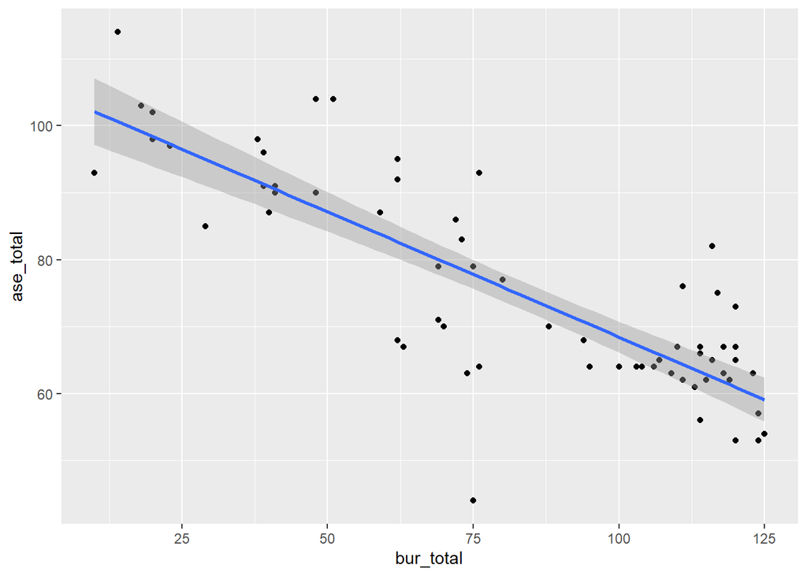

```r
burnout_df %>%
  ggplot(aes(x = bur_total,
             y = ase_total)) +
  geom_point() +
  geom_smooth(method = lm)
```

> <sup>Las variables presentan una relación lineal negativa</sup>

##### *Evaluar el supuesto de normalidad (Shapiro-Wilk test)*

```r
shapiro.test(burnout_df$bur_total)
```

```
##
##  Shapiro-Wilk normality test
##
## data:  burnout_df$bur_total
## W = 0.89722, p-value = 3.403e-05
```

```r
shapiro.test(burnout_df$ase_total)
```

```
##
##  Shapiro-Wilk normality test
##
## data:  burnout_df$ase_total
## W = 0.92585, p-value = 0.0005314
```

##### *Evaluar el supuesto de normalidad (histograma)*

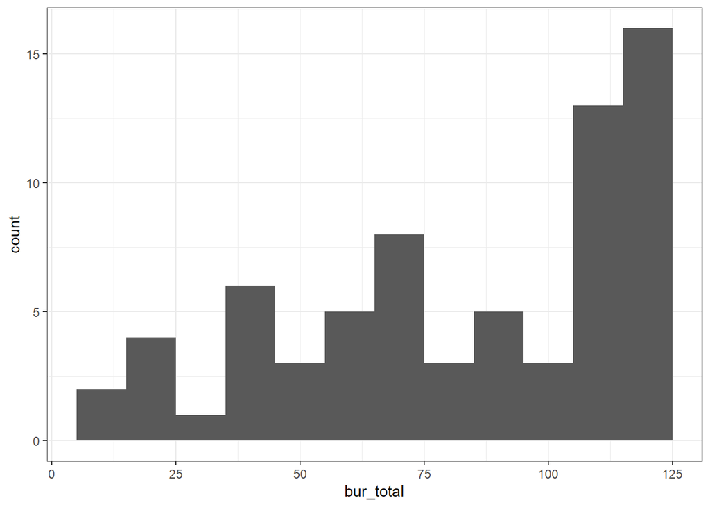

```r
# Burnout
burnout_df %>%
  ggplot(aes(x = bur_total)) +
  geom_histogram(binwidth = 10) +
  theme_bw()
```

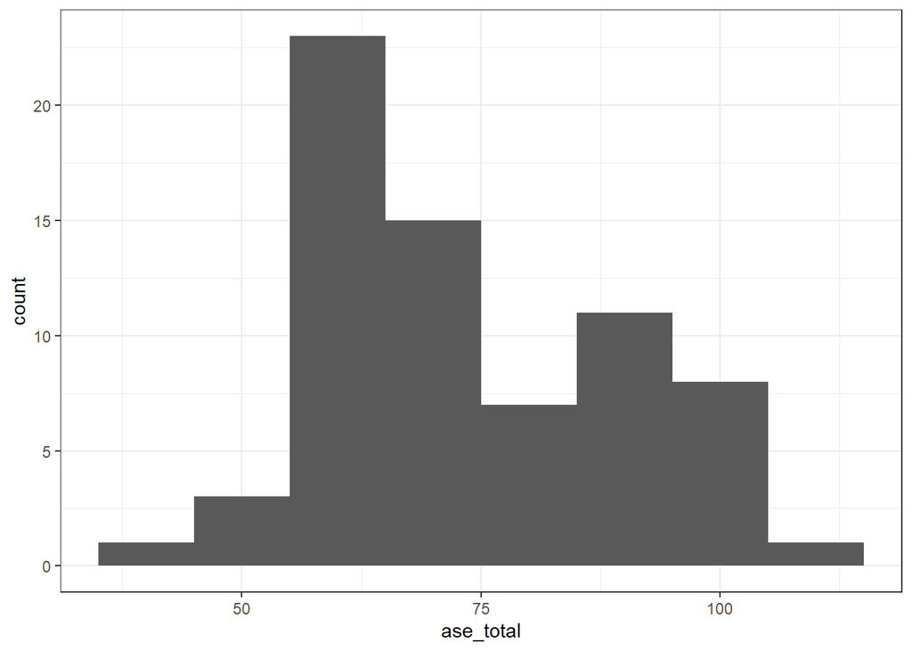

```r
# Autoeficacia académica
burnout_df %>%
  ggplot(aes(x = ase_total)) +
  geom_histogram(binwidth = 10) +
  theme_bw()
```

> <sup>Las variables no cumplen con el supuesto de normalidad, por lo que se utilizará una prueba no paramétrica (Spearman)</sup>

##### *Análisis de correlación (Spearman)*

```r
burnout_df %>%
  select(bur_total, ase_total) %>%
  correlate(method = "spearman")
```

| term | bur_total | ase_total |
| --- | --- | --- |
| bur_total | NA | -0.7901693 |
| ase_total | -0.7901693 | NA |

> <sup>Las variables presentan una fuerte correlación negativa es decir, a mayor puntaje burnout menor de autoeficacia académica</sup>